# Determinantes del salario y de la informalidad laboral en Argentina

- Mostrar todo el código
- Ocultar todo el código
- Ver el código fuente

Trabajo Final — Pre-procesamiento de datos

Autor/a

Lautaro Sanfilippo

Fecha de publicación

24 de junio de 2026

# 1 Introducción

El mercado laboral argentino se caracteriza por una marcada **heterogeneidad salarial** y una elevada **informalidad** (empleo no registrado). Entender qué explica el salario de las personas y qué determina la probabilidad de trabajar en la informalidad es una de las preguntas centrales de la economía laboral, y tiene consecuencias directas de política pública: dónde concentrar la fiscalización, qué grupos quedan más desprotegidos, cuánto rinde realmente estudiar.

Este trabajo aborda las dos preguntas sobre **microdatos reales** de la Encuesta Permanente de Hogares (EPH), recorriendo el flujo completo de pre-procesamiento, análisis exploratorio y modelado. Se ajustan dos modelos complementarios:

- un **modelo de regresión lineal** para el (log) salario horario, que cuantifica cuánto vale cada característica de la persona y su empleo, y
- un **modelo de regresión logística** para la probabilidad de ser informal.

La **informalidad** cumple un doble rol que vale la pena anticipar: es la **variable a explicar** en el modelo logístico y, al mismo tiempo, una **variable explicativa** del modelo de salarios, porque se espera que, a igualdad de las demás características, los trabajadores informales ganen menos.

# 2 Los datos

## 2.1 Fuente

Los datos provienen de la **Encuesta Permanente de Hogares (EPH)** que elabora el **INDEC**. Es una encuesta continua que releva 31 aglomerados urbanos y publica microdatos abiertos y anonimizados con periodicidad trimestral. Se usa la **base de individuos del 4.º trimestre de 2025** (el último período disponible al momento de hacer el trabajo), que se descarga directamente desde el INDEC con el paquete [`eph`](https://holatam.github.io/eph/). De este modo el informe se reproduce de punta a punta: la descarga, la limpieza y todos los modelos corren dentro de este mismo documento.

**Ver código**

```r
cruda <- get_microdata(year = 2025, period = 4, type = "individual")
```

La base original tiene **43.703 personas** y **235 variables**. A partir de ella se construye una base analítica restringida a la población de interés, que se describe a continuación.

## 2.2 Objetivos

1. **Explicar el salario horario** de las personas asalariadas en función de su capital humano y de las características de su empleo, midiendo en particular los retornos a la educación, la brecha salarial de género y la penalización asociada a la informalidad.
2. **Modelar la probabilidad de informalidad laboral** con esas mismas características y evaluar qué tan bien el modelo logra distinguir a un trabajador formal de uno informal.

## 2.3 Las variables

A partir de la base original se arma una base analítica con las siguientes variables (su construcción se detalla en la sección de pre-procesamiento):

Variables de la base analítica.

| Variable | Tipo | Rol | Definición |
| --- | --- | --- | --- |
| salario_horario | Numérica continua | Respuesta (lineal) | Ingreso de la ocupación principal por hora: P21 / (horas × 4,33) |
| log_salario | Numérica continua | Respuesta (lineal) | Logaritmo natural del salario horario |
| informal | Categórica binaria | Respuesta (logística) / Predictora (lineal) | Empleo no registrado (sin descuento jubilatorio) |
| nivel_ed | Categórica (6 niveles) | Predictora | Máximo nivel educativo alcanzado |
| edad | Numérica discreta | Predictora | Edad en años (entra también al cuadrado) |
| sexo | Categórica binaria | Predictora | Sexo registrado (Varón / Mujer) |
| tamano_estab | Categórica (4 niveles) | Predictora | Tamaño del establecimiento |
| region | Categórica (6 niveles) | Predictora | Región del país |
| sector | Categórica (12 ramas) | Auxiliar (donante de imputación) | Rama de actividad (clasificación CAES-EPH) |
| horas | Numérica | Auxiliar | Horas semanales trabajadas (definen el salario horario) |

# 3 Pre-procesamiento

La población objetivo son las personas **asalariadas ocupadas de 18 a 65 años**. La restricción tiene un motivo claro: el salario horario solo está definido para quien percibe una remuneración, y la informalidad —medida por el descuento jubilatorio— es un concepto propio del empleo asalariado. El rango etario deja afuera a menores y a personas en edad jubilatoria, como es habitual al estudiar salarios.

## 3.1 Tratamiento de los datos faltantes

El punto más delicado del pre-procesamiento son los **códigos especiales** de la EPH, que el software no reconoce como faltantes porque son números reales: un `999` de horas o un `-9` de ingreso contaminarían el análisis si se los tomara literalmente. La clave es que **no todos significan lo mismo**, así que se los trata según lo que representan.

### 3.1.1 Ingreso: “no responde” (−9) ≠ “no percibió ingreso” (0)

Una distinción central es que el código `-9` (la persona **no quiso o no supo responder** su ingreso) **no es lo mismo** que el `0` (la persona **declara no haber percibido ingreso** en el período):

- **`P21 == -9` (no respuesta):** es un **faltante genuino**. Como el ingreso es la **variable respuesta**, no corresponde imputarlo: se lo trata por **análisis de casos completos**, es decir, se excluyen esos casos.
- **`P21 == 0` (sin ingreso):** **no es un faltante.** Son ocupados que declararon no percibir ingreso laboral en el período (en general con muy poca antigüedad en el puesto). Constituyen **otra población**, ajena a una ecuación de salarios (además su salario horario sería 0, indefinido en logaritmo), así que se los **excluye**.

Antes de excluir a quienes no responden conviene preguntarse por el **mecanismo de pérdida**: si la no respuesta dependiera de las características observadas (faltante MAR), el análisis de casos completos podría sesgar las estimaciones. Para evaluarlo se comparan las **características observables** de quienes responden y quienes no, tal como sugiere la bibliografía cuando se sospecha un mecanismo de pérdida:

Características observables de quienes responden y no responden el ingreso (asalariados de 18 a 65 años).

| Grupo | Casos | Edad media | % Mujer | % Con superior | Horas semanales |
| --- | --- | --- | --- | --- | --- |
| No responde | 2.401 | 39,7 | 44,3 | 41,4 | 37,6 |
| Responde | 11.220 | 40,0 | 47,9 | 39,9 | 36,5 |

Los grupos resultan **muy parecidos** en edad, composición por sexo, nivel educativo y horas trabajadas: la no respuesta no muestra una dependencia clara con lo observado, lo que vuelve razonable el análisis de casos completos. Aun así, esta comparación solo descarta una dependencia con las variables **observadas**: no puede descartarse que quienes más ganan tiendan a no declarar (un faltante **no aleatorio**, MNAR, imposible de verificar con los propios datos), lo que se retoma en las limitaciones.

### 3.1.2 Flujo de casos

El siguiente cuadro muestra cuántas observaciones se descartan en cada etapa y por qué. El conteo es secuencial, de modo que las bajas suman exactamente hasta la base final.

**Ver código**

```r
e0 <- cruda |> filter(ESTADO == 1, CAT_OCUP == 3, CH06 >= 18, CH06 <= 65)
e1 <- e0 |> filter(P21 != -9)
e2 <- e1 |> filter(P21 != 0)
e3 <- e2 |> filter(!PP3E_TOT %in% c(0, 999), !is.na(PP3E_TOT))

base <- e3 |>
  organize_caes() |>
  transmute(
    salario_mensual = P21,
    salario_horario = P21 / (PP3E_TOT * 4.33),
    log_salario     = log(salario_horario),
    informal = factor(if_else(PP07H == 2, "Informal", "Formal"),
                      levels = c("Formal", "Informal")),
    edad  = CH06,
    horas = PP3E_TOT,
    sexo  = factor(if_else(CH04 == 1, "Varón", "Mujer"), levels = c("Varón", "Mujer")),
    nivel_ed = factor(case_when(
      NIVEL_ED %in% c(7, 1) ~ "Primario incompleto o menos",
      NIVEL_ED == 2 ~ "Primario completo",
      NIVEL_ED == 3 ~ "Secundario incompleto",
      NIVEL_ED == 4 ~ "Secundario completo",
      NIVEL_ED == 5 ~ "Superior incompleto",
      NIVEL_ED == 6 ~ "Superior completo"),
      levels = c("Primario incompleto o menos", "Primario completo",
                 "Secundario incompleto", "Secundario completo",
                 "Superior incompleto", "Superior completo")),
    region = factor(case_when(
      REGION == 1 ~ "GBA", REGION == 40 ~ "NOA", REGION == 41 ~ "NEA",
      REGION == 42 ~ "Cuyo", REGION == 43 ~ "Pampeana", REGION == 44 ~ "Patagonia"),
      levels = c("GBA", "Pampeana", "NOA", "NEA", "Cuyo", "Patagonia")),
    sector = caes_eph_label,
    tamano_estab = factor(case_when(
      PP04C == 0                 ~ "Casa particular",
      PP04C %in% 1:5             ~ "Chico (hasta 5)",
      PP04C %in% 6:8             ~ "Mediano (6 a 40)",
      PP04C %in% 9:12            ~ "Grande (más de 40)",
      PP04C == 99 & PP04C99 == 1 ~ "Chico (hasta 5)",
      PP04C == 99 & PP04C99 == 2 ~ "Mediano (6 a 40)",
      PP04C == 99 & PP04C99 == 3 ~ "Grande (más de 40)",
      TRUE                       ~ NA_character_),
      levels = c("Chico (hasta 5)", "Mediano (6 a 40)", "Grande (más de 40)",
                 "Casa particular")))
```

Flujo de casos hasta la base analítica final.

| Etapa | Casos |
| --- | --- |
| Asalariados ocupados de 18 a 65 años | 13.621 |
| (−) No responde el ingreso (−9) | -2.401 |
| (−) Declara no percibir ingreso (0) | -159 |
| (−) Horas no válidas (0 / 999 / faltante) | -198 |
| Base analítica final | 10.863 |

La base analítica final tiene **10.863 asalariados**. Conviene notar que la no respuesta de ingresos es alta —cerca del **18%** de los asalariados—, un dato que pesa al interpretar el modelo de salarios. Hecha la limpieza, la única variable con faltantes es el tamaño del establecimiento, que se imputa a continuación.

### 3.1.3 Tamaño del establecimiento: códigos, recupero e imputación

El tamaño del establecimiento es un predictor relevante (hay una **prima salarial por tamaño de empresa** y se asocia fuertemente con la formalidad), pero tiene no respuesta. Su tratamiento requirió leer con cuidado el cuestionario:

- El código `99` (no sabe / no responde) aparecía en buena parte de los casos, pero la EPH incluye una **pregunta de recupero** que captura un tramo grueso (hasta 5 / de 6 a 40 / más de 40) para quien no precisó el tramo fino. Tras el recupero, la no respuesta real baja a **5.7%** (622 casos).
- El código `0` corresponde **únicamente a trabajadores de servicio doméstico** (casas particulares), para quienes no aplica la idea de establecimiento. No es un faltante: se lo trata como categoría propia (**“Casa particular”**).

Como los 622 faltantes son **todos no domésticos**, imputarlos es un problema de tres niveles (Chico / Mediano / Grande). Para no atarse a un único método, se imputó con **KNN (k = 5)**, **missForest** e **imputación múltiple MICE (m = 5)**, usando como donantes las variables completas (incluida la respuesta `log_salario`, lo que ayuda a preservar la relación entre la predictora y el salario). Las distribuciones imputadas resultan **estables entre métodos** y parecidas a la distribución observada:

**Ver código**

```r
suppressMessages({library(VIM); library(missForest); library(mice)})

donantes <- c("log_salario", "informal", "sexo", "edad",
              "nivel_ed", "region", "sector", "horas")
niv3 <- c("Chico (hasta 5)", "Mediano (6 a 40)", "Grande (más de 40)")

dom <- base |> filter(tamano_estab == "Casa particular")
nd  <- base |> filter(is.na(tamano_estab) | tamano_estab != "Casa particular")
nd$tamano3 <- droplevels(factor(nd$tamano_estab, levels = niv3))
idx_na <- which(is.na(nd$tamano3))
df <- nd[, c("tamano3", donantes)]

set.seed(2026)
imp_knn <- kNN(df, variable = "tamano3", dist_var = donantes, k = 5, imp_var = FALSE)$tamano3[idx_na]
set.seed(2026)
imp_mf  <- missForest(as.data.frame(df))$ximp$tamano3[idx_na]
mice_out <- mice(df, m = 5, method = "polyreg", printFlag = FALSE, seed = 2026)
imp_mice <- complete(mice_out, "long")$tamano3[complete(mice_out, "long")$.id %in% idx_na]

imp_cmp <- rbind(
  Observada    = 100 * as.numeric(prop.table(table(droplevels(na.omit(nd$tamano3))))),
  KNN          = 100 * as.numeric(prop.table(table(imp_knn))),
  missForest   = 100 * as.numeric(prop.table(table(imp_mf))),
  `MICE (m=5)` = 100 * as.numeric(prop.table(table(imp_mice)))
) |> as.data.frame()
colnames(imp_cmp) <- niv3

nd$tamano_estab <- as.character(nd$tamano_estab)
nd$tamano_estab[idx_na] <- as.character(imp_knn)
nd$tamano3 <- NULL
datos <- bind_rows(nd, dom) |>
  mutate(tamano_estab = factor(tamano_estab,
    levels = c(niv3, "Casa particular")))
```

Distribución (%) del tamaño del establecimiento: observada vs. imputada.

| Distribución | Chico (hasta 5) | Mediano (6 a 40) | Grande (más de 40) |
| --- | --- | --- | --- |
| Observada | 21,9 | 39,4 | 38,7 |
| KNN | 21,2 | 43,7 | 35,0 |
| missForest | 23,3 | 40,8 | 35,9 |
| MICE (m=5) | 24,4 | 42,2 | 33,4 |

Las tres distribuciones imputadas son muy parecidas entre sí y consistentes con la observada, así que la elección del método casi no mueve la composición de la variable. Se adopta la imputación por **KNN** para el análisis. (Más adelante, en la validación cruzada, la imputación se rehace dentro del conjunto de entrenamiento para no filtrar información).

### 3.1.4 Efecto del método de imputación sobre la inferencia

Que las distribuciones imputadas coincidan no alcanza: importa también el efecto sobre la **inferencia**, en particular sobre los **intervalos de confianza**. La imputación simple (KNN, missForest) trata los valores imputados como si fueran observados y, por lo tanto, **subestima la varianza** de los estimadores (intervalos demasiado angostos). La **imputación múltiple (MICE)** corrige esto con las reglas de Rubin, que suman a la incertidumbre habitual la variabilidad *entre* las distintas imputaciones. Para verlo, se ajusta el modelo de salarios bajo cada método y se comparan los coeficientes de la variable imputada (el tamaño) y el **ancho de sus intervalos al 95 %**:

**Ver código**

```r
form_s <- log_salario ~ nivel_ed + edad + I(edad^2) + sexo + informal +
            tamano_estab + region

rehacer <- function(t3) {
  nd2 <- nd
  nd2$tamano_estab <- factor(as.character(t3), levels = c(niv3, "Casa particular"))
  bind_rows(nd2, dom)
}
extraer <- function(m, metodo) {
  s <- summary(m)$coefficients; ci <- confint.default(m)
  f <- grep("tamano_estab", rownames(s))
  data.frame(metodo, termino = gsub("tamano_estab", "", rownames(s)[f]),
             est = s[f, 1], se = s[f, 2], ancho = ci[f, 2] - ci[f, 1],
             row.names = NULL)
}

set.seed(2026)
knn2 <- kNN(df, variable = "tamano3", dist_var = donantes, k = 5, imp_var = FALSE)$tamano3
set.seed(2026)
mf2  <- missForest(as.data.frame(df))$ximp$tamano3
mice20 <- mice(df, m = 20, method = "polyreg", printFlag = FALSE, seed = 2026)

fits <- lapply(1:20, function(i) lm(form_s, rehacer(complete(mice20, i)$tamano3)))
coefs <- sapply(fits, coef); vars <- sapply(fits, \(f) diag(vcov(f)))
Qbar <- rowMeans(coefs); Ubar <- rowMeans(vars); B <- apply(coefs, 1, var)
se_r <- sqrt(Ubar + (1 + 1/20) * B)
f <- grep("tamano_estab", names(Qbar))
r_mice <- data.frame(metodo = "MICE (múltiple)", termino = gsub("tamano_estab", "", names(Qbar)[f]),
                     est = Qbar[f], se = se_r[f], ancho = 2 * 1.96 * se_r[f], row.names = NULL)

comp_inf <- bind_rows(
  extraer(lm(form_s, base),          "Casos completos"),
  extraer(lm(form_s, rehacer(knn2)), "KNN (simple)"),
  extraer(lm(form_s, rehacer(mf2)),  "missForest (simple)"),
  r_mice
) |> filter(termino %in% c("Mediano (6 a 40)", "Grande (más de 40)"))
```

Efecto del método de imputación sobre la estimación y la precisión.

| Coeficiente (vs. Chico) | Método | Estimación | Error estándar | Ancho IC 95 % |
| --- | --- | --- | --- | --- |
| Grande (más de 40) | Casos completos | 0,1878 | 0,0159 | 0,0622 |
| Grande (más de 40) | KNN (simple) | 0,1811 | 0,0155 | 0,0606 |
| Grande (más de 40) | MICE (múltiple) | 0,1852 | 0,0158 | 0,0620 |
| Grande (más de 40) | missForest (simple) | 0,1907 | 0,0155 | 0,0609 |
| Mediano (6 a 40) | Casos completos | 0,1032 | 0,0147 | 0,0578 |
| Mediano (6 a 40) | KNN (simple) | 0,1031 | 0,0143 | 0,0562 |
| Mediano (6 a 40) | MICE (múltiple) | 0,1022 | 0,0148 | 0,0579 |
| Mediano (6 a 40) | missForest (simple) | 0,1048 | 0,0144 | 0,0563 |

Las **estimaciones puntuales** son prácticamente iguales entre métodos. La diferencia aparece en la **precisión**: los intervalos más angostos son los de la **imputación simple** (KNN, missForest), que trata los valores imputados como observados, mientras que **MICE y los casos completos producen los más anchos** —MICE porque incorpora la incertidumbre de la imputación (es ~3% más ancho que KNN), y los casos completos porque descartan observaciones y pierden tamaño muestral—. La diferencia es chica porque solo se imputa una predictora y en pocos casos; con más faltantes, quedarse con la imputación simple subestimaría la varianza de forma mucho más peligrosa. En síntesis, usar KNN para el análisis principal es razonable y no cambia las conclusiones, pero queda documentada la advertencia metodológica.

## 3.2 Recodificación de categorías

Varias variables se recodificaron a etiquetas legibles (todo dentro del bloque que construye la base): el **nivel educativo** unió “Sin instrucción” y “Primario incompleto” en una sola categoría por la baja frecuencia de la primera (quedan 6 niveles); **sexo**, **región** e **informalidad** pasaron de códigos numéricos a etiquetas; y el **tamaño** y el **sector** se trataron como se explicó arriba.

El nivel educativo, aunque tiene un orden natural, se trata como **factor no ordenado**: así se evita que el modelo genere contrastes polinómicos y cada nivel se interpreta de manera directa contra una categoría de referencia.

## 3.3 Variable derivada: el salario horario

La respuesta del modelo lineal es ella misma una **variable derivada**: el salario horario combina el ingreso mensual de la ocupación principal (`P21`) con las horas semanales trabajadas (`PP3E_TOT`),

$$\text{salario\_horario} = \frac{P21}{PP3E\_TOT \times 4{,}33},$$

donde 4,33 ≈ semanas promedio por mes. De ella se deriva su logaritmo (`log_salario`), que se justifica en la sección siguiente. Al modelo se le agrega, además, el **término cuadrático de la edad** (`edad²`) para capturar el perfil no lineal entre salario y edad (la experiencia rinde, pero cada vez menos).

## 3.4 Transformación logarítmica

El salario horario muestra la fuerte **asimetría a derecha** típica de los ingresos: muchos valores bajos y una cola larga de valores altos. El logaritmo la corrige notablemente.

Asimetría y curtosis antes y después del logaritmo.

| Variable | Asimetría | Curtosis |
| --- | --- | --- |
| Salario horario | 4,01 | 34,66 |
| log(Salario horario) | -0,13 | 1,07 |

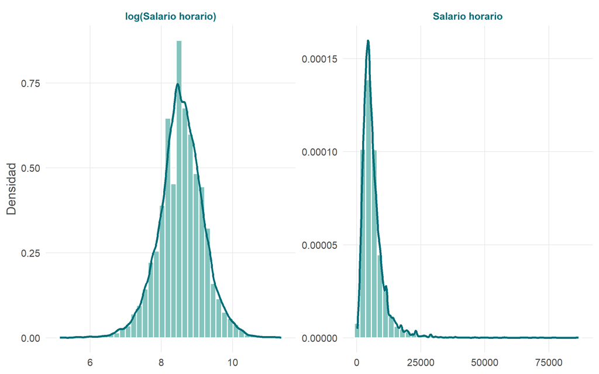

Distribución del salario horario en escala original y logarítmica.

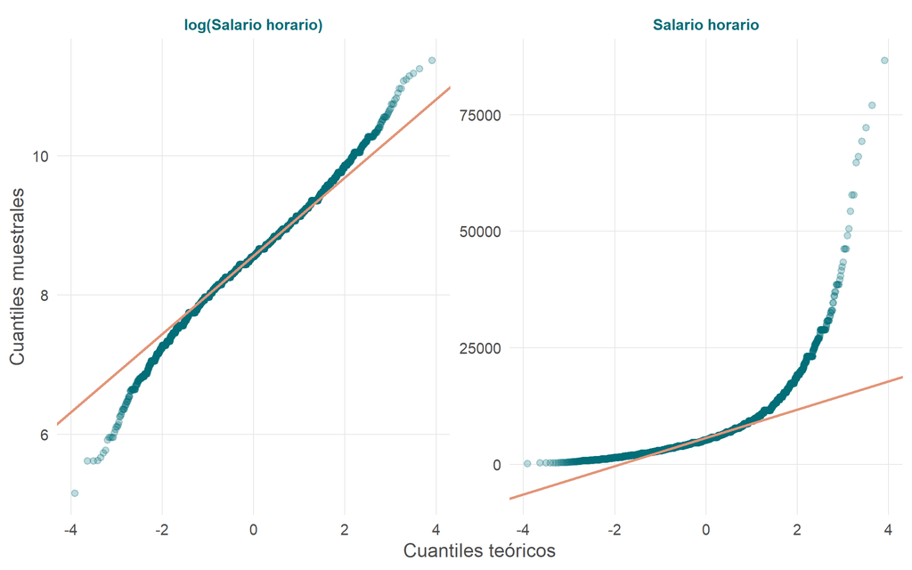

Gráficos Q-Q normales: en escala logarítmica los cuantiles se alinean.

La asimetría pasa de alrededor de 4 a casi 0 y la curtosis cae de forma drástica: en escala logarítmica la distribución es prácticamente simétrica y mucho más cercana a la normal, como confirma el Q-Q. Con un tamaño muestral tan grande, los tests formales de normalidad rechazarían igual ante desvíos mínimos, por lo que la evaluación se apoya en los gráficos y en las medidas de forma. Se modela, entonces, **`log_salario`**, lo que además le da a los coeficientes una lectura **porcentual** muy cómoda para el análisis económico.

## 3.5 Escala de las variables

Para la regresión por mínimos cuadrados **no hace falta estandarizar**: con predictoras mayormente categóricas y una continua (`edad`), los coeficientes se leen directamente en sus unidades. La estandarización se reservaría para comparar magnitudes entre predictoras o para métodos penalizados (Ridge/Lasso), sensibles a la escala, que se prueban más adelante.

## 3.6 Valores atípicos

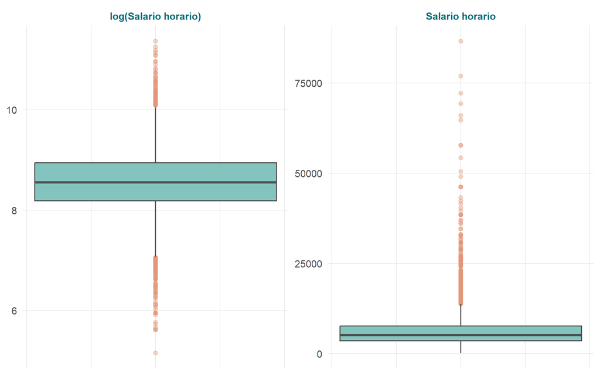

Box-plots: los atípicos extremos de la escala original se atenúan en log.

Cantidad de valores atípicos según la regla del rango intercuartílico.

| Escala | Atípicos (regla 1,5·RIC) | % del total |
| --- | --- | --- |
| Salario horario | 637 | 5,9 |
| log(Salario horario) | 273 | 2,5 |

Al mirar los salarios horarios más altos se ve que **muchos son un artefacto del denominador**: surgen de muy pocas horas declaradas (que inflan el cociente), no necesariamente de ingresos extraordinarios.

Los seis salarios horarios más altos: las pocas horas declaradas inflan el cociente.

| Salario mensual | Horas | Salario horario | Nivel educativo | Informal |
| --- | --- | --- | --- | --- |
| 3,0e+06 | 8 | 86.605 | Superior incompleto | Informal |
| 2,0e+06 | 6 | 76.982 | Secundario completo | Informal |
| 1,0e+07 | 32 | 72.171 | Superior completo | Formal |
| 1,5e+07 | 50 | 69.284 | Superior completo | Formal |
| 8,0e+06 | 28 | 65.985 | Superior completo | Formal |
| 7,0e+06 | 25 | 64.665 | Secundario completo | Informal |

**Decisión.** No se eliminan observaciones solo por ser atípicas: no hay certeza de que sean errores (podrían ser ingresos altos genuinos o empleos de pocas horas). El tratamiento principal es la **transformación logarítmica**, que reduce los atípicos de 637 a alrededor de 273 y atenúa su influencia. Los casos que quedan se conservan y su impacto sobre el ajuste se evalúa formalmente en el diagnóstico del modelo (distancia de Cook, leverage); recién ahí, y con evidencia de influencia desmedida, se consideraría un tratamiento adicional.

# 4 Análisis exploratorio

## 4.1 Las variables a explicar

La distribución de `log_salario` ya se mostró arriba (aproximadamente simétrica). En cuanto a la informalidad, algo más de un tercio de los asalariados es informal:

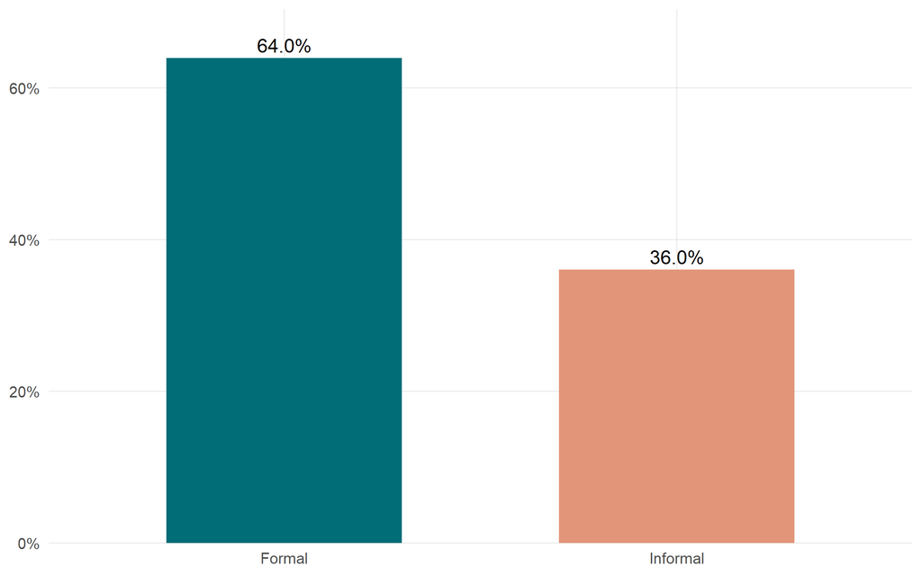

Distribución de la informalidad laboral.

## 4.2 El salario según las características

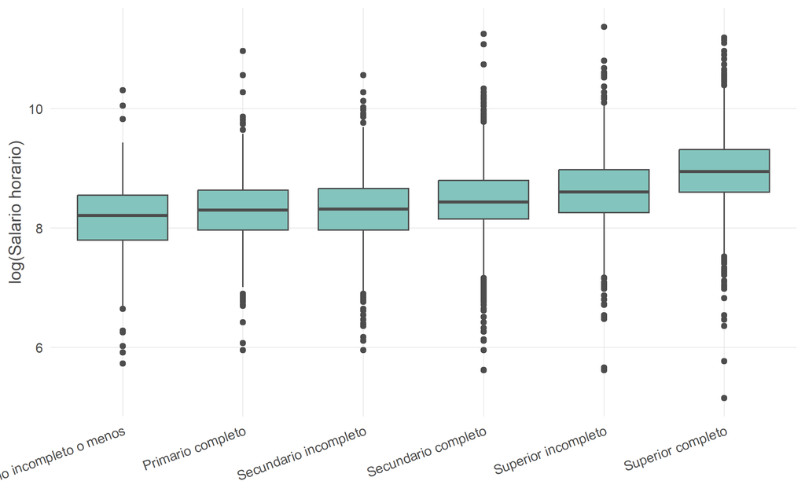

Salario (log) según nivel educativo.

El salario crece de manera monótona con el nivel educativo, lo que anticipa **retornos positivos a la educación**.

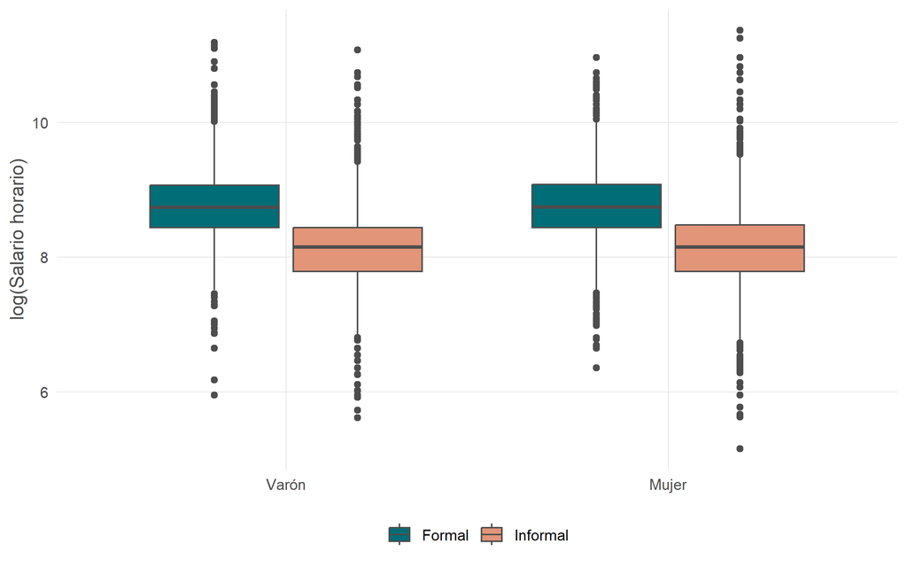

Salario (log) según sexo y condición de informalidad.

Acá aparece con claridad la **penalización por informalidad**: los formales ganan bastante más que los informales, en ambos sexos. En cambio, la **brecha de género se ve casi nula a nivel marginal** (las medianas por sexo casi coinciden). El resultado, llamativo a primera vista, se explica porque las mujeres de la muestra tienen en promedio **mayor nivel educativo** (48% con estudios superiores frente a 32% de los varones), lo que compensa y **enmascara** la brecha cuando se mira todo junto. Como se ve enseguida, al condicionar por educación la brecha sí aparece.

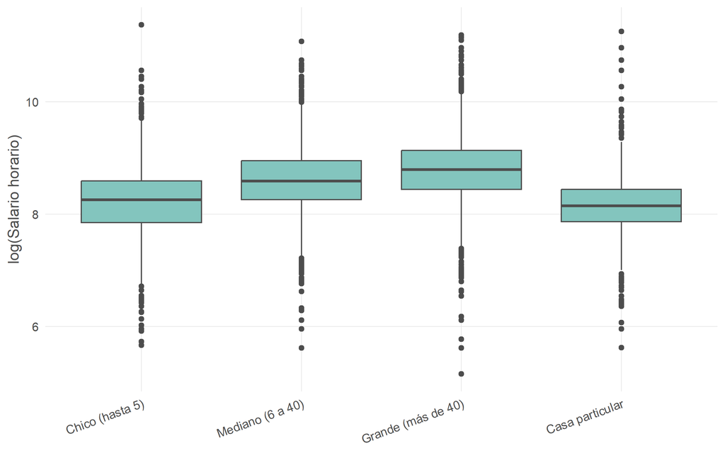

Salario (log) según tamaño del establecimiento.

Se ve la **prima por tamaño**: a mayor tamaño del establecimiento, mayor salario. El servicio doméstico (“Casa particular”) muestra los salarios más bajos.

## 4.3 La forma de la relación salario–edad

Antes de meter la edad al cuadrado en el modelo conviene verificar que la relación lo amerite. El perfil es **cóncavo** (crece, llega a un máximo y se aplana), como muestra el suavizado:

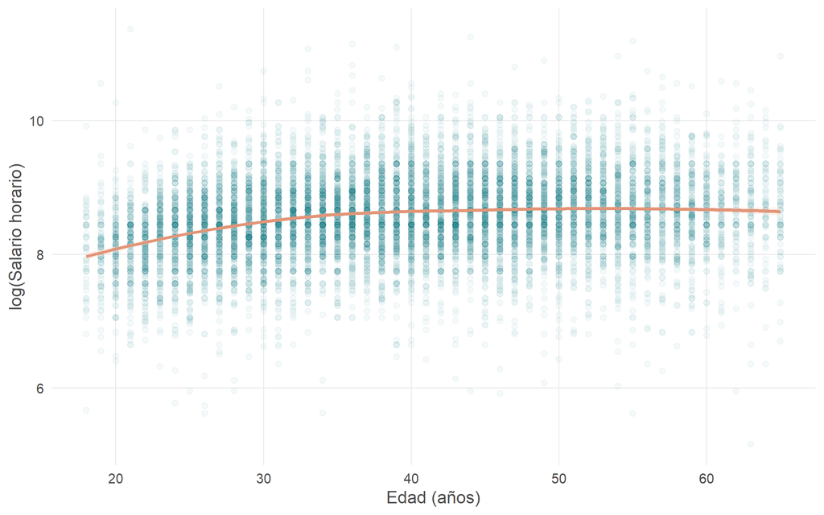

Salario (log) según edad, con suavizado loess: perfil cóncavo.

El contraste formal confirma que la **especificación cuadrática** mejora de manera significativa sobre la lineal, aun controlando por el resto de las variables, mientras que el término cúbico aporta apenas:

Comparación de especificaciones de la edad (controlando por el resto).

| Modelo | Res.Df | RSS | Df | Sum of Sq | F | Pr(>F) |
| --- | --- | --- | --- | --- | --- | --- |
| + edad | 10.846 | 2.613,8 | — | — | — | — |
| + edad² | 10.845 | 2.603,1 | 1 | 10,7 | 44,53 | 0,0000 |
| + edad³ | 10.844 | 2.601,7 | 1 | 1,3 | 5,59 | 0,0181 |

La cuadrática es altamente significativa y, aunque la cúbica también lo es, su aporte es ínfimo; por **parsimonia e interpretabilidad** se elige la cuadrática. Según ella, el salario alcanza su máximo alrededor de los **57 años**, un valor económicamente razonable (la experiencia rinde con rendimientos decrecientes). Queda justificado incluir `edad²`.

## 4.4 La informalidad según las características

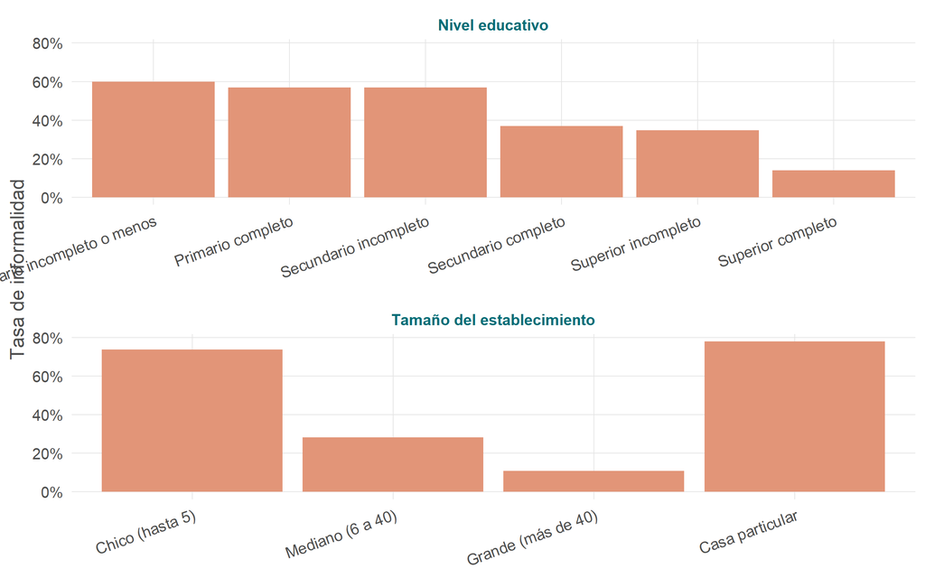

Tasa de informalidad según nivel educativo y tamaño del establecimiento.

La informalidad **baja con el nivel educativo** y es mucho menor en establecimientos grandes (y máxima en el servicio doméstico). Esto anticipa el peso que tendrán estas variables en el modelo logístico.

## 4.5 La brecha de género por nivel educativo

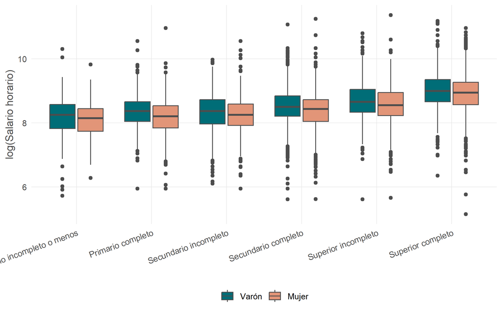

Salario (log) por nivel educativo y sexo.

Acá **sí** se aprecia la brecha: **dentro de cada nivel educativo los varones ganan más que las mujeres**. La brecha es entonces un fenómeno **condicional**: a nivel agregado quedaba tapada por la mayor educación femenina, pero emerge al comparar a igualdad de nivel educativo. Esto motiva con fuerza el enfoque multivariado y sugiere explorar una posible **interacción** educación × sexo en el modelo.

# 5 Modelo de regresión lineal

## 5.1 Especificación y ajuste

Se plantea un modelo de **regresión lineal múltiple** para el logaritmo del salario horario:

$$\log(\text{salario}_i) = \beta_0 + \beta_1\,\text{edad}_i + \beta_2\,\text{edad}_i^2
+ \delta\,\text{mujer}_i + \theta\,\text{informal}_i
+ \boldsymbol{\gamma}'\mathbf{educ}_i
+ \boldsymbol{\tau}'\mathbf{tam}_i
+ \boldsymbol{\rho}'\mathbf{reg}_i + \varepsilon_i.$$

Las variables `mujer` e `informal` son **indicadoras** (valen 1 o 0). La educación, el tamaño y la región son categóricas que entran como **conjuntos de indicadoras**: cada coeficiente mide la diferencia respecto de una **categoría de referencia** —*Primario incompleto o menos* (educación), *Varón* (sexo), *Formal* (registro), *Chico (hasta 5)* (tamaño) y *GBA* (región)—. El modelo se ajusta así:

**Ver código**

```r
m_base <- lm(log_salario ~ nivel_ed + edad + I(edad^2) + sexo + informal +
               tamano_estab + region, data = datos)
```

Ajuste inicial por mínimos cuadrados. R² = 0.389; R² ajustado = 0.388.

|  | Término | Estimación | Error estándar | t | p-valor |
| --- | --- | --- | --- | --- | --- |
| (Intercept) | (Intercept) | 7,7490 | 0,0671 | 115,4911 | 0,0000 |
| nivel_edPrimario completo | nivel_edPrimario completo | 0,0699 | 0,0366 | 1,9107 | 0,0561 |
| nivel_edSecundario incompleto | nivel_edSecundario incompleto | 0,1359 | 0,0354 | 3,8415 | 0,0001 |
| nivel_edSecundario completo | nivel_edSecundario completo | 0,1969 | 0,0344 | 5,7160 | 0,0000 |
| nivel_edSuperior incompleto | nivel_edSuperior incompleto | 0,3601 | 0,0359 | 10,0310 | 0,0000 |
| nivel_edSuperior completo | nivel_edSuperior completo | 0,5745 | 0,0352 | 16,3199 | 0,0000 |
| edad | edad | 0,0261 | 0,0028 | 9,1849 | 0,0000 |
| I(edad^2) | I(edad^2) | -0,0002 | 0,0000 | -6,6715 | 0,0000 |
| sexoMujer | sexoMujer | -0,0664 | 0,0104 | -6,3988 | 0,0000 |
| informalInformal | informalInformal | -0,3050 | 0,0125 | -24,4081 | 0,0000 |
| tamano_estabMediano (6 a 40) | tamano_estabMediano (6 a 40) | 0,1031 | 0,0143 | 7,1882 | 0,0000 |
| tamano_estabGrande (más de 40) | tamano_estabGrande (más de 40) | 0,1811 | 0,0155 | 11,7086 | 0,0000 |
| tamano_estabCasa particular | tamano_estabCasa particular | -0,0510 | 0,0199 | -2,5657 | 0,0103 |
| regionPampeana | regionPampeana | -0,0483 | 0,0149 | -3,2443 | 0,0012 |
| regionNOA | regionNOA | -0,2332 | 0,0153 | -15,2865 | 0,0000 |
| regionNEA | regionNEA | -0,2716 | 0,0212 | -12,7875 | 0,0000 |
| regionCuyo | regionCuyo | -0,1811 | 0,0195 | -9,3053 | 0,0000 |
| regionPatagonia | regionPatagonia | 0,2353 | 0,0183 | 12,8259 | 0,0000 |

Como la respuesta es el **logaritmo** del salario, un coeficiente $\beta$ se traduce en un **cambio porcentual** del salario igual a $(e^{\beta}-1)\times 100\,\%$, **manteniendo todo lo demás constante**. Todos los coeficientes tienen el signo esperado y la mayoría son significativos; la lectura cuantitativa detallada, con intervalos de confianza y solo de los efectos significativos, se presenta una vez validados los supuestos. El $R^2$ ronda **0.39**, un valor habitual para ecuaciones de salarios con datos de corte transversal.

## 5.2 La brecha de género: del dato marginal al condicional

En el análisis exploratorio aparecía una aparente paradoja: la brecha de género se veía **casi nula** al mirar el total, pero **visible al separar por nivel educativo**. ¿Es contradictorio que ahora el sexo sí sea significativo? No, y el modelo permite entender por qué. La tabla muestra cómo cambia el coeficiente de *Mujer* a medida que se agregan controles:

Coeficiente de 'Mujer' según los controles incluidos.

|  | Especificación | Coef. Mujer | Error estándar | p-valor | Efecto aprox. |
| --- | --- | --- | --- | --- | --- |
| Estimate | Solo sexo (marginal) | -0,0320 | 0,0120 | 0,0079 | -3.1% |
| Estimate1 | + educación | -0,1244 | 0,0111 | 0,0000 | -11.7% |
| Estimate2 | + edad | -0,1401 | 0,0107 | 0,0000 | -13.1% |
| Estimate3 | Modelo completo | -0,0664 | 0,0104 | 0,0000 | -6.4% |

Sin controles, la brecha es de apenas ~3 %. **Al sumar la educación se multiplica por casi cuatro** (de −3 % a ~−12 %): como las mujeres de la muestra están más educadas, su mayor calificación **enmascaraba** la brecha a nivel agregado. Es un caso de **supresión**: una variable (educación) correlacionada positivamente tanto con ser mujer como con el salario ocultaba el efecto real del sexo; al controlarla, la brecha aparece. En el modelo completo, al sumar informalidad, tamaño y región, la brecha se modera pero **sigue siendo significativa**: es la parte de la diferencia salarial que **no** explican las características observadas.

Queda una pregunta distinta: ¿la brecha *cambia* entre niveles educativos? Eso es lo que evalúa el término de interacción educación × sexo:

Test de la interacción educación × sexo.

| Modelo | Res.Df | RSS | Df | Sum of Sq | F | Pr(>F) |
| --- | --- | --- | --- | --- | --- | --- |
| Aditivo | 10.845 | 2.603,1 | — | — | — | — |
| + interacción educación × sexo | 10.840 | 2.602,1 | 5 | 1 | 0,84 | 0,5215 |

La interacción **no es significativa**: la brecha **existe pero es aproximadamente constante** entre niveles educativos. Por eso alcanza con una única brecha de género —el modelo aditivo—.

## 5.3 Selección de variables

Se aplica una selección **paso a paso en ambas direcciones** con los criterios **AIC** y **BIC**. El procedimiento parte del modelo completo (con la interacción) y en cada paso evalúa tanto quitar como agregar términos, quedándose con el cambio que más mejora el criterio. En lugar de volcar la traza de la consola, se resume en una tabla los pasos efectivos:

**Ver código**

```r
full <- lm(log_salario ~ nivel_ed * sexo + edad + I(edad^2) + informal +
             tamano_estab + region, data = datos)
sel_aic <- MASS::stepAIC(full, direction = "both", trace = FALSE, k = 2)
sel_bic <- MASS::stepAIC(full, direction = "both", trace = FALSE, k = log(nrow(datos)))
```

Pasos de la selección por AIC (dirección: ambas).

| Paso | g.l. | Desviación | g.l. residuales | AIC |
| --- | --- | --- | --- | --- |
| Modelo inicial | — | — | 10.840 | -15.477,8 |
| - nivel_ed:sexo | 5 | 1 | 10.845 | -15.483,6 |

El único movimiento que mejora el criterio es **quitar la interacción**; después, ni eliminar variables ni volver a agregar la interacción mejora nada, y el algoritmo se detiene. (Los valores de AIC de esta tabla provienen de `stepAIC`/`extractAIC`, que omiten una constante aditiva, por lo que están en otra escala que los de la tabla comparativa de más abajo —calculados con `AIC()`—; lo comparable entre ambas son las **diferencias** entre modelos, no los valores absolutos: en las dos, el aditivo mejora al modelo con interacción en ~5,8 puntos). Como verificación, al **quitar cada término de a uno** del modelo aditivo, todos empeoran significativamente el ajuste, lo que confirma que **ninguna variable sobra**:

Eliminación de un término por vez sobre el modelo aditivo.

| Término | g.l. | Suma de cuad. | F | p-valor |
| --- | --- | --- | --- | --- |
| nivel_ed | 5 | 296,772 | 247,284 | 0 |
| edad | 1 | 20,249 | 84,363 | 0 |
| I(edad^2) | 1 | 10,683 | 44,509 | 0 |
| sexo | 1 | 9,828 | 40,945 | 0 |
| informal | 1 | 142,996 | 595,755 | 0 |
| tamano_estab | 3 | 44,832 | 62,259 | 0 |
| region | 5 | 241,950 | 201,604 | 0 |

Comparación de modelos por distintos criterios.

| Modelo | N.º coef. | R² aj. | AIC | BIC |
| --- | --- | --- | --- | --- |
| Aditivo (base) | 18 | 0,3885 | 15.346,2 | 15.484,8 |
| Con interacción | 23 | 0,3884 | 15.352,0 | 15.527,1 |
| Selección AIC | 18 | 0,3885 | 15.346,2 | 15.484,8 |
| Selección BIC | 18 | 0,3885 | 15.346,2 | 15.484,8 |

Tanto **AIC como BIC eligen el mismo modelo aditivo**: retienen todas las predictoras y descartan únicamente la interacción. Se adopta, entonces, el **modelo aditivo** como modelo de trabajo.

### 5.3.1 Regresión penalizada (Ridge y Lasso)

Como **método alternativo de ajuste**, se prueba la **regresión penalizada**, útil cuando hay mucha multicolinealidad o demasiadas predictoras. Se ajustan **Ridge** y **Lasso** eligiendo la penalización $\lambda$ por validación cruzada y se compara su error de predicción contra el de mínimos cuadrados:

**Ver código**

```r
library(glmnet)
Xp <- model.matrix(formula(m_base), datos)[, -1]
yp <- datos$log_salario
set.seed(2026)
cvl <- cv.glmnet(Xp, yp, alpha = 1)
cvr <- cv.glmnet(Xp, yp, alpha = 0)
nz  <- sum(as.matrix(coef(cvl, s = "lambda.min"))[-1, 1] != 0)
set.seed(2026); fk <- sample(rep(1:10, length.out = nrow(datos)))
mse_ols <- mean(sapply(1:10, function(i) {
  mm <- lm(formula(m_base), datos[fk != i, ])
  mean((datos$log_salario[fk == i] - predict(mm, datos[fk == i, ]))^2)
}))
```

Regresión penalizada vs. mínimos cuadrados.

| Método | λ (validación cruzada) | Variables retenidas | Error de predicción (CV) |
| --- | --- | --- | --- |
| Mínimos cuadrados | — | 17 | 0,2406 |
| Ridge | 0.0296 | 17 | 0,2422 |
| Lasso | 0.00013 | 17 | 0,2406 |

El $\lambda$ óptimo de Lasso es prácticamente nulo y **retiene todas las variables**, mientras que el error de predicción es **equivalente** al de mínimos cuadrados (Ridge resulta incluso algo peor). La penalización **no aporta**: como había muchos más casos que predictoras y sin multicolinealidad relevante, no hay varianza que reducir ni variables que descartar. Sumado a que los coeficientes penalizados no se interpretan en términos del problema, se mantiene el **modelo de mínimos cuadrados** como modelo final.

## 5.4 Diagnóstico de los supuestos

La validez de la inferencia depende de los supuestos sobre los errores, que se evalúan a partir de los **residuos** del modelo aditivo.

**Independencia.** Los datos son un **corte transversal** (un único trimestre), así que no hay estructura temporal que genere autocorrelación. Sí cabe señalar que la EPH tiene un diseño por conglomerados que aquí no se modela (se retoma en las limitaciones).

**Linealidad y homocedasticidad.** El gráfico de residuos contra valores ajustados no muestra curvatura (la linealidad, ayudada por el log y `edad²`, es razonable), pero sí cierta variación no constante:

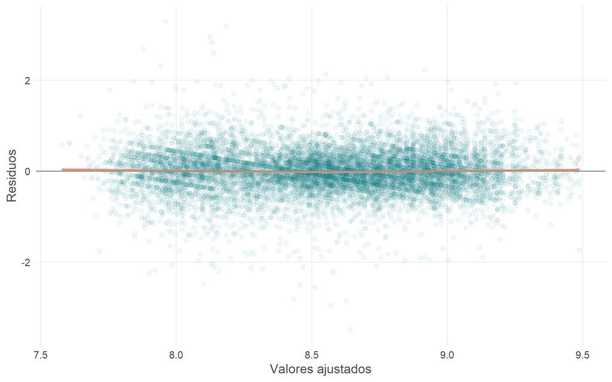

Residuos vs. valores ajustados.

**Ver código**

```r
lmtest::bptest(m_base)
```

```
    studentized Breusch-Pagan test

data:  m_base
BP = 376.52, df = 17, p-value < 2.2e-16
```

El test de **Breusch-Pagan rechaza** la homocedasticidad: hay **heterocedasticidad**, algo habitual en datos salariales. Esto no sesga los coeficientes, pero **invalida los errores estándar clásicos**, así que más abajo se usan errores estándar robustos.

**Normalidad de los residuos.**

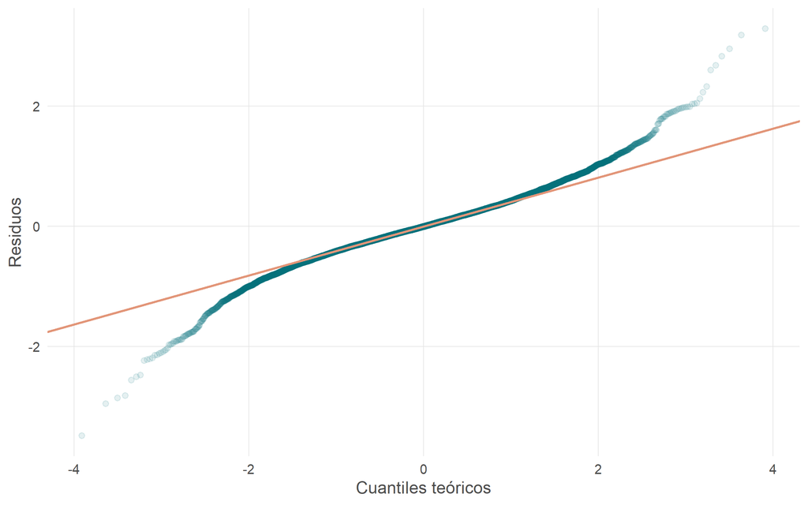

Q-Q normal de los residuos del modelo.

**Ver código**

```r
r <- resid(m_base)
c(Asimetría = mean(((r - mean(r)) / sd(r))^3),
  `Curtosis (exceso)` = mean(((r - mean(r)) / sd(r))^4) - 3)
```

```
        Asimetría Curtosis (exceso)
      -0.02325667        2.93904011
```

Los residuos son **simétricos** (asimetría ≈ 0) pero con **colas marcadamente más pesadas** que la normal (exceso de curtosis ≈ 2,9). Un test formal rechazaría la normalidad, pero con un tamaño muestral tan grande detecta desvíos mínimos; como hay más de diez mil observaciones, por el Teorema Central del Límite la distribución de los estimadores es aproximadamente normal y la inferencia se mantiene válida.

**Observaciones influyentes.** Se evalúan con la distancia de Cook y el leverage:

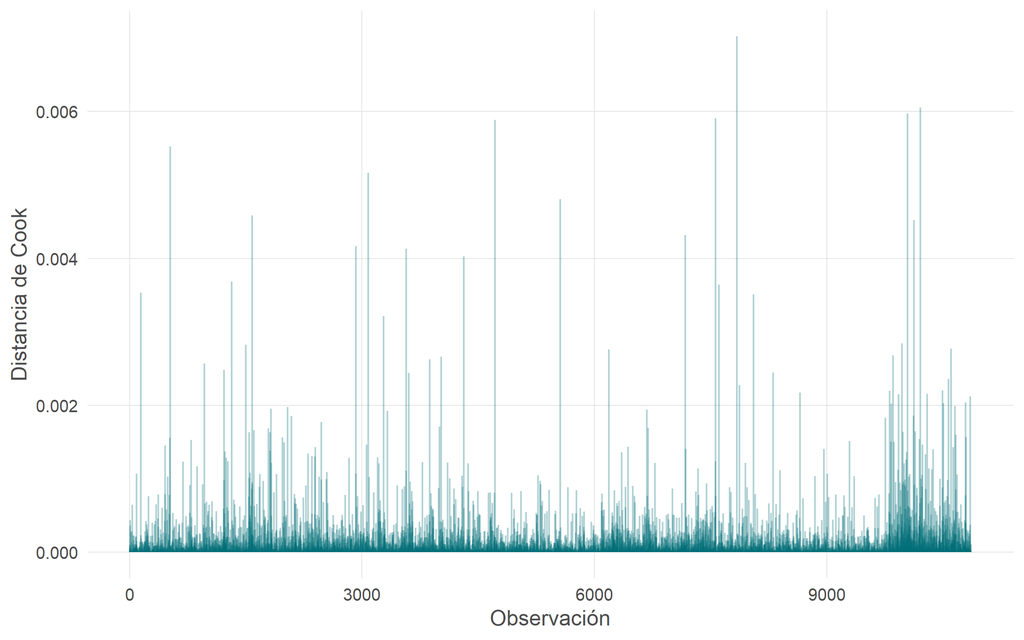

Distancia de Cook por observación (ninguna se acerca al umbral 1).

Diagnóstico de observaciones influyentes.

| Criterio | Valor |
| --- | --- |
| Distancia de Cook > 1 | 0,000 |
| Leverage > 2p/n | 242,000 |
| Máx. distancia de Cook | 0,007 |

**Ningún punto es influyente**: la distancia de Cook máxima está muy por debajo de 1. Esto **confirma la decisión del pre-procesamiento**: los salarios atípicos que se conservaron no distorsionan el ajuste (el logaritmo atenúa su efecto), así que no corresponde eliminarlos.

**Multicolinealidad.**

Factores de inflación de la varianza (GVIF).

| Variable | GVIF | GVIF^(1/2·gl) |
| --- | --- | --- |
| nivel_ed | 1,39 | 1,03 |
| edad | 50,56 | 7,11 |
| I(edad^2) | 49,69 | 7,05 |
| sexo | 1,22 | 1,10 |
| informal | 1,63 | 1,28 |
| tamano_estab | 1,83 | 1,11 |
| region | 1,06 | 1,01 |

El único valor alto es el de `edad` y `edad²`, algo **esperable y benigno**: están correlacionados por construcción (es el mismo predictor al cuadrado) y no afecta ni las predicciones ni el contraste conjunto del efecto de la edad. El resto no presenta multicolinealidad.

**Errores estándar robustos.** Por la heterocedasticidad, se reestiman los errores con la corrección de White (HC1). Como muestra la tabla, son **del mismo orden** que los clásicos —el mayor cambio se da en *Superior completo*, donde el robusto es algo mayor— y **ninguna conclusión cambia**:

Errores estándar clásicos vs. robustos (HC1), coeficientes seleccionados.

| Variable | SE clásico | SE robusto | p robusto |
| --- | --- | --- | --- |
| Superior completo | 0,0352 | 0,0433 | 0 |
| Mujer | 0,0104 | 0,0102 | 0 |
| Informal | 0,0125 | 0,0139 | 0 |
| Tamaño grande | 0,0155 | 0,0155 | 0 |
| Patagonia | 0,0183 | 0,0189 | 0 |

En síntesis, el modelo es adecuado: la única violación relevante es la heterocedasticidad, que se corrige con errores robustos sin alterar las conclusiones; el apartamiento de la normalidad es inocuo dado el tamaño muestral, y no hay observaciones influyentes ni multicolinealidad problemática.

## 5.5 Modelo final e interpretación

El modelo final es el **modelo aditivo** seleccionado, estimado con **errores estándar robustos (HC1)**. Explica un **39 %** de la variabilidad del log-salario. La tabla resume el **efecto porcentual** de cada característica sobre el salario, con sus intervalos de confianza al 95 %, manteniendo todo lo demás constante:

Modelo final: efecto porcentual sobre el salario (IC 95 % robustos). Referencias: Primario incompleto o menos, Varón, Formal, Chico (hasta 5), GBA.

| Variable | Efecto (%) | IC 95 % inf. (%) | IC 95 % sup. (%) |
| --- | --- | --- | --- |
| Educación: Primario completo | 7,2 | -1,7 | 17,0 |
| Educación: Secundario incompleto | 14,6 | 5,2 | 24,7 |
| Educación: Secundario completo | 21,8 | 12,0 | 32,3 |
| Educación: Superior incompleto | 43,4 | 31,5 | 56,2 |
| Educación: Superior completo | 77,6 | 63,2 | 93,4 |
| Sexo: Mujer | -6,4 | -8,3 | -4,5 |
| Informalidad: Informal | -26,3 | -28,3 | -24,3 |
| Tamaño: Mediano | 10,9 | 7,7 | 14,1 |
| Tamaño: Grande | 19,9 | 16,3 | 23,6 |
| Tamaño: Casa particular | -5,0 | -9,1 | -0,7 |
| Región: Pampeana | -4,7 | -7,8 | -1,5 |
| Región: NOA | -20,8 | -23,4 | -18,1 |
| Región: NEA | -23,8 | -27,1 | -20,3 |
| Región: Cuyo | -16,6 | -19,9 | -13,1 |
| Región: Patagonia | 26,5 | 21,9 | 31,3 |

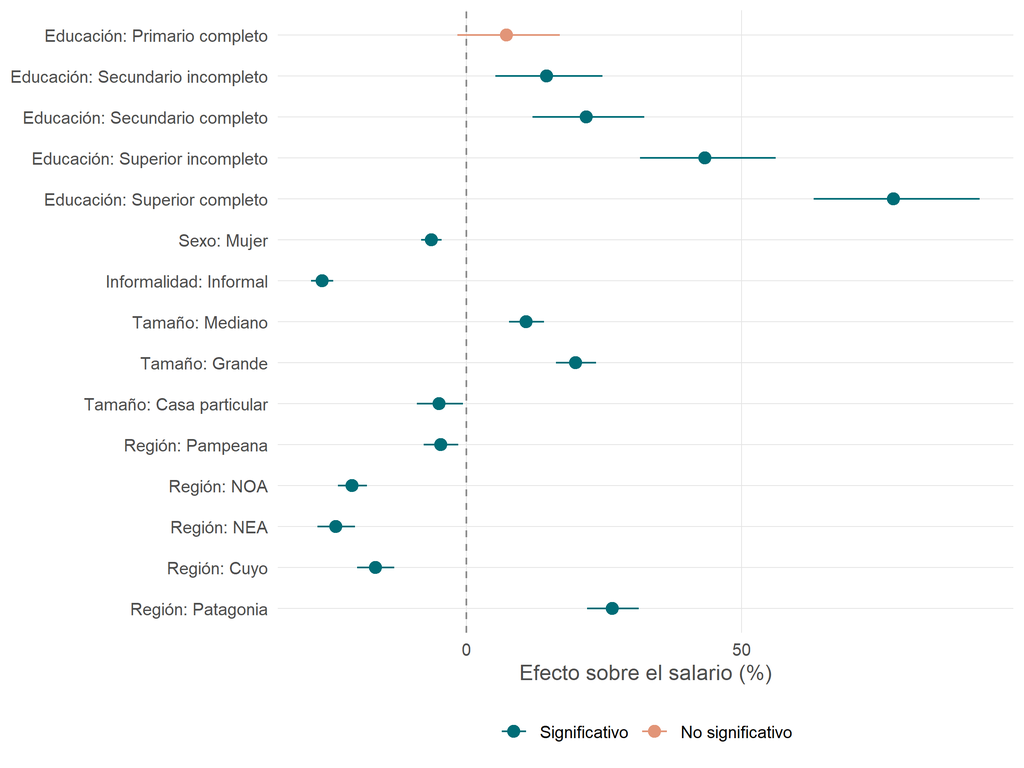

Efecto porcentual sobre el salario con IC 95 % robustos. En anaranjado, los efectos no significativos (su intervalo contiene el 0).

El gráfico permite leer de un vistazo la magnitud, la precisión y la significatividad de cada efecto. A continuación se interpretan **solo los significativos**:

**Retornos a la educación.** El salario crece de forma **monótona** con el nivel educativo. El primer escalón (*Primario completo*) **no es significativo**: no hay evidencia de que se distinga de quienes tienen, a lo sumo, primario incompleto. A partir de *Secundario incompleto* todos lo son: completar el secundario se asocia a un salario **~22 % mayor** y el superior completo a uno **~78 % mayor** respecto de la referencia. Es, junto con la informalidad, el determinante más fuerte del salario.

**Perfil de edad.** El efecto de la edad es **cóncavo** (positivo en `edad`, negativo en `edad²`): el salario sube con la edad —reflejo de la experiencia acumulada— a una tasa decreciente, llega a su máximo cerca de los **57 años** y después baja levemente.

**Brecha de género.** A igualdad de educación, edad, informalidad, tamaño y región, las **mujeres ganan alrededor de 6% menos** que los varones. Es una brecha **condicional** y significativa: la parte de la diferencia salarial que no explican las características observadas.

**Prima por tamaño.** Respecto de los establecimientos chicos, los medianos pagan **~11 % más** y los grandes **~20 % más**; el servicio doméstico queda por debajo de los chicos.

**Diferencias regionales.** Tomando el GBA como referencia, el **NOA, NEA y Cuyo pagan menos** (entre ~17 % y ~24 %) y la **Pampeana** algo menos (~5 %), mientras que la **Patagonia paga ~27 % más**, consistente con su mayor costo de vida y su estructura productiva.

**En términos del problema.** El modelo cumple el primer objetivo: confirma **retornos crecientes a la educación**, un **perfil cóncavo de edad**, y señala como factores de mayor peso a la **informalidad** y a la **educación superior**. Persiste una **brecha de género** que las demás variables no explican, y se verifican primas por **tamaño** y diferencias **regionales** marcadas.

# 6 Modelo de regresión logística

## 6.1 Especificación y ajuste

Se modela la probabilidad de que una persona ocupada tenga un **empleo informal** (no registrado) mediante regresión logística (enlace *logit*), tomando “Informal” como el resultado a predecir. Se usan las mismas predictoras que en el modelo de salarios **excepto el salario**: la informalidad es una *causa* del salario y no al revés, de modo que incluirlo sería controlar por una consecuencia y distorsionaría las estimaciones.

**Ver código**

```r
g <- glm(informal ~ nivel_ed + edad + I(edad^2) + sexo + tamano_estab + region,
         family = binomial(link = "logit"), data = datos)
```

## 6.2 Interpretación en razones de odds

Exponenciando cada coeficiente se obtiene la **razón de odds (OR)**: por cuánto se multiplica la *chance* de ser informal ante esa característica, respecto de la categoría de referencia y manteniendo lo demás constante. Un OR < 1 indica menor chance de informalidad; un OR > 1, mayor.

Razones de odds de informalidad (IC 95 %). Referencias: Primario incompleto o menos, Varón, Chico (hasta 5), GBA.

| Variable | OR | IC 95 % inf. | IC 95 % sup. |
| --- | --- | --- | --- |
| Educación: Primario completo | 0,990 | 0,685 | 1,432 |
| Educación: Secundario incompleto | 0,711 | 0,497 | 1,017 |
| Educación: Secundario completo | 0,335 | 0,236 | 0,474 |
| Educación: Superior incompleto | 0,312 | 0,217 | 0,449 |
| Educación: Superior completo | 0,186 | 0,130 | 0,267 |
| Sexo: Mujer | 1,076 | 0,961 | 1,203 |
| Tamaño: Mediano | 0,165 | 0,144 | 0,187 |
| Tamaño: Grande | 0,057 | 0,049 | 0,066 |
| Tamaño: Casa particular | 1,514 | 1,241 | 1,847 |
| Región: Pampeana | 0,708 | 0,603 | 0,831 |
| Región: NOA | 1,323 | 1,125 | 1,554 |
| Región: NEA | 1,024 | 0,818 | 1,281 |
| Región: Cuyo | 1,941 | 1,585 | 2,378 |
| Región: Patagonia | 0,369 | 0,298 | 0,456 |

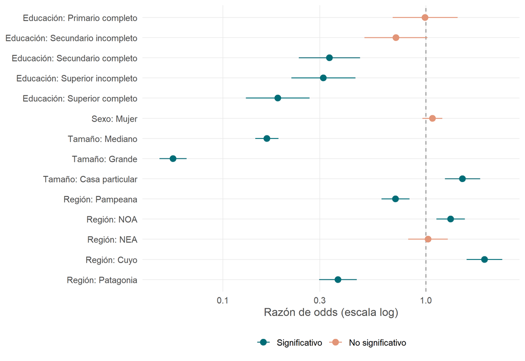

Razones de odds de informalidad con IC 95 % (escala logarítmica). En anaranjado, los efectos no significativos (su intervalo contiene el 1).

La edad entra de forma **cuadrática**, así que su razón de odds “por año” no es directamente interpretable y por eso se la dejó fuera de la tabla y del gráfico anteriores (su significatividad se verifica más abajo). Su efecto se aprecia mejor mirando la **probabilidad estimada de informalidad a lo largo de la edad**, promediando el resto de las características sobre la muestra:

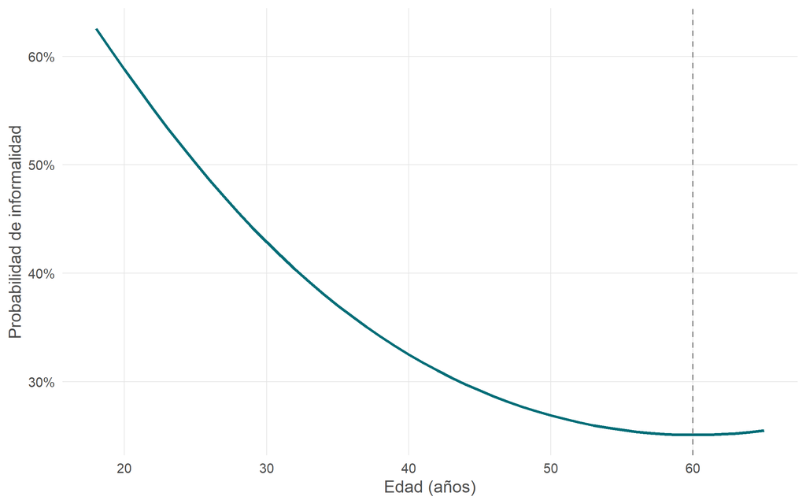

Probabilidad estimada de informalidad según la edad (promediando el resto de las características sobre la muestra). La línea punteada marca el mínimo.

Interpretando **solo los efectos significativos**:

- **Tamaño del establecimiento** (ref.: *Chico*): es el factor dominante. En los establecimientos **grandes la chance de informalidad es alrededor de un 94 % menor** y en los medianos cerca de un 84 % menor; el **servicio doméstico** tiene más chance que los chicos.
- **Educación** (ref.: *Primario incompleto o menos*): a mayor nivel, menor chance de informalidad; con *Superior completo* la chance es alrededor de **un 81 % menor**. El efecto es significativo a partir de *Secundario completo*.
- **Edad**: como muestra la figura anterior, la informalidad **decrece marcadamente con la edad** —los jóvenes son mucho más informales— hasta alcanzar su mínimo cerca de los **60 años**, con un leve repunte posterior (efecto convexo). Tanto `edad` como `edad²` son significativas (se verifica más abajo).
- **Región** (ref.: *GBA*): mayor informalidad en **Cuyo** y **NOA**; menor en **Patagonia** y **Pampeana**.
- **Sexo**: **no significativo**. A igualdad del resto, varones y mujeres tienen una chance de informalidad similar.

## 6.3 Significación y selección de variables

El modelo es **globalmente significativo** frente al modelo sin predictoras, según el test de razón de verosimilitud (preferible al de Wald en regresión logística):

Test de razón de verosimilitud: modelo vs. modelo nulo.

| #Df | LogLik | Df | Chisq | Pr(>Chisq) |
| --- | --- | --- | --- | --- |
| 1 | -7.101,1 | — | — | — |
| 17 | -4.736,5 | 16 | 4.729,2 | 0 |

Para ver el aporte de cada variable, se la elimina de a una y se contrasta por razón de verosimilitud:

Aporte de cada variable (test de razón de verosimilitud).

| Término | g.l. | LRT | p-valor |
| --- | --- | --- | --- |
| nivel_ed | 5 | 389,589 | 0,000 |
| edad | 1 | 114,392 | 0,000 |
| I(edad^2) | 1 | 52,450 | 0,000 |
| sexo | 1 | 1,614 | 0,204 |
| tamano_estab | 3 | 2.216,890 | 0,000 |
| region | 5 | 298,245 | 0,000 |

Todas las variables aportan significativamente **excepto el sexo**. Es un contraste interesante con el modelo de salarios: el sexo **influye en el nivel salarial** (brecha de género) pero **no en la probabilidad de informalidad**. Por parsimonia, el modelo final excluye el sexo:

**Ver código**

```r
g_final <- glm(informal ~ nivel_ed + edad + I(edad^2) + tamano_estab + region,
               family = binomial(link = "logit"), data = datos)
```

## 6.4 Capacidad predictiva

**Ver código**

```r
suppressMessages({library(pROC); library(nnet)})
form_g <- informal ~ nivel_ed + edad + I(edad^2) + tamano_estab + region

metricas <- function(obs, prob, corte) {
  pred <- factor(ifelse(prob >= corte, "Informal", "Formal"), levels = c("Formal", "Informal"))
  VP <- sum(pred == "Informal" & obs == "Informal"); FP <- sum(pred == "Informal" & obs == "Formal")
  FN <- sum(pred == "Formal"   & obs == "Informal"); VN <- sum(pred == "Formal"   & obs == "Formal")
  n <- VP + FP + FN + VN; po <- (VP + VN) / n
  pe <- ((VP + FN) / n) * ((VP + FP) / n) + ((FP + VN) / n) * ((FN + VN) / n)
  sens <- VP / (VP + FN); spec <- VN / (VN + FP); ppv <- VP / (VP + FP); npv <- VN / (VN + FN)
  c(Exactitud = po, Sensibilidad = sens, Especificidad = spec, VPP = ppv, VPN = npv,
    F1 = 2 * ppv * sens / (ppv + sens), Kappa = (po - pe) / (1 - pe))
}

prob_is <- predict(g_final, type = "response")
roc_is  <- roc(datos$informal, prob_is, levels = c("Formal", "Informal"), direction = "<", quiet = TRUE)
corte   <- as.numeric(coords(roc_is, "best", best.method = "youden", ret = "threshold")[1])

niv3 <- c("Chico (hasta 5)", "Mediano (6 a 40)", "Grande (más de 40)")
don_cv <- c("log_salario", "sexo", "edad", "nivel_ed", "region", "sector")
base$es_dom <- !is.na(base$tamano_estab) & base$tamano_estab == "Casa particular"
imputar <- function(tr, te) {
  tr_fit <- tr |> filter(!es_dom, !is.na(tamano_estab))
  mod <- multinom(reformulate(don_cv, "t3"),
                  data = transform(tr_fit, t3 = droplevels(factor(tr_fit$tamano_estab, levels = niv3))),
                  trace = FALSE)
  fill <- function(d) {
    na_nd <- !d$es_dom & is.na(d$tamano_estab)
    if (any(na_nd)) d$tamano_estab[na_nd] <- as.character(predict(mod, d[na_nd, ]))
    factor(d$tamano_estab, levels = c(niv3, "Casa particular"))
  }
  list(tr = fill(tr), te = fill(te))
}

set.seed(2026)
k <- 10
fold <- integer(nrow(base))
for (lv in levels(base$informal)) {
  idx <- which(base$informal == lv)
  fold[idx] <- sample(rep(1:k, length.out = length(idx)))
}
oof <- rep(NA_real_, nrow(base))
for (i in 1:k) {
  tr <- base[fold != i, ]; te <- base[fold == i, ]
  imp <- imputar(tr, te)
  tr$tamano_estab <- imp$tr; te$tamano_estab <- imp$te
  g_cv <- glm(form_g, family = binomial("logit"), data = tr)
  oof[fold == i] <- predict(g_cv, te, type = "response")
}
roc_cv <- roc(base$informal, oof, levels = c("Formal", "Informal"), direction = "<", quiet = TRUE)
corte_cv <- as.numeric(coords(roc_cv, "best", best.method = "youden", ret = "threshold")[1])
```

Para ver qué tan bien el modelo **clasifica** a las personas como formales o informales se usan las probabilidades ajustadas y una regla de decisión.

**Curva ROC y AUC.** La curva ROC resume el desempeño para todos los puntos de corte posibles; el área bajo la curva (AUC) mide la capacidad de discriminación:

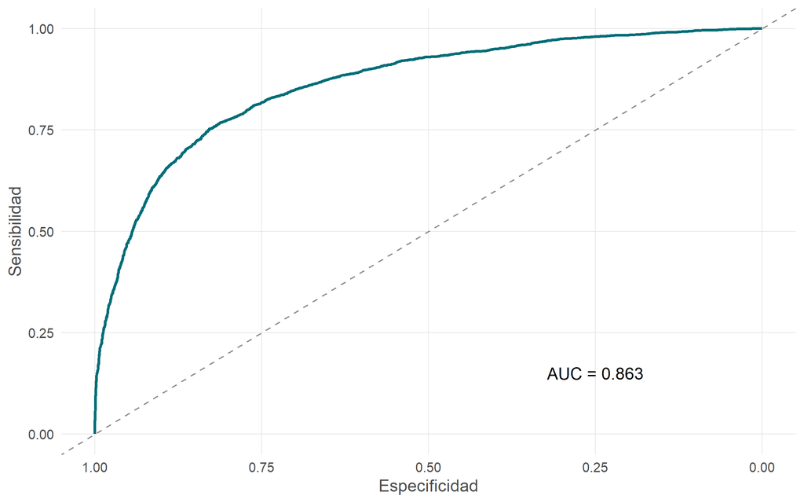

Curva ROC del modelo de informalidad.

El **AUC ≈ 0.86** indica una **buena capacidad de discriminación** (muy por encima del 0,5 de una clasificación al azar).

**Punto de corte.** Con el corte habitual de 0,5 el modelo es algo conservador para detectar informales. El **corte óptimo de Youden** (0.39), que maximiza a la vez sensibilidad y especificidad, mejora la detección:

Métricas de clasificación. Corte óptimo de Youden = 0.394.

| Regla | Exactitud | Sensibilidad | Especificidad | VPP | VPN | F1 | Kappa |
| --- | --- | --- | --- | --- | --- | --- | --- |
| Corte 0,5 | 0,805 | 0,674 | 0,879 | 0,759 | 0,827 | 0,714 | 0,567 |
| Corte óptimo | 0,801 | 0,752 | 0,829 | 0,712 | 0,856 | 0,732 | 0,574 |

Matriz de confusión con el corte óptimo.

| Predicho \ Observado | Formal | Informal | Sum |
| --- | --- | --- | --- |
| Formal | 5.756 | 970 | 6.726 |
| Informal | 1.191 | 2.946 | 4.137 |
| Sum | 6.947 | 3.916 | 10.863 |

Con el corte óptimo, el modelo alcanza una **sensibilidad de alrededor de 0,75** (detecta 3 de cada 4 informales) y una **especificidad de alrededor de 0,83**, con una concordancia moderada (Kappa ≈ 0,57).

**Validación cruzada.** Para estimar el desempeño en datos nuevos —y descartar sobreajuste— se aplica **validación cruzada estratificada de 10 folds**. Lo importante es que la **imputación del tamaño se rehace dentro de cada fold** (usando solo el conjunto de entrenamiento y sin la variable `informal` como donante), de modo de no filtrar información hacia la predicción. Para que la imputación se ajuste y aplique limpiamente dentro de cada partición se usa aquí un modelo de **regresión multinomial** sobre los donantes (en lugar del KNN del análisis principal); como se vio antes, la elección del método casi no mueve la distribución del tamaño, así que esto no condiciona los resultados:

Desempeño en los datos de ajuste vs. validación cruzada (10 folds, imputación dentro de cada fold).

| Evaluación | AUC | Exactitud | Sensibilidad | Especificidad | VPP | VPN | F1 | Kappa |
| --- | --- | --- | --- | --- | --- | --- | --- | --- |
| Datos de ajuste | 0,863 | 0,801 | 0,752 | 0,829 | 0,712 | 0,856 | 0,732 | 0,574 |
| Validación cruzada | 0,859 | 0,796 | 0,754 | 0,820 | 0,702 | 0,855 | 0,727 | 0,565 |

Las métricas de validación cruzada son **casi idénticas** a las de ajuste (AUC ≈ 0,86 en ambos casos): el modelo **no está sobreajustado** y mantiene su capacidad predictiva en datos no vistos. Que la imputación dentro de cada fold no altere los resultados confirma, además, que el tratamiento de faltantes **no infla** artificialmente el desempeño.

**En términos del problema.** El modelo logístico identifica correctamente los determinantes de la informalidad —sobre todo el **tamaño del establecimiento** y la **educación**— y, con un AUC de alrededor de 0,86 validado por validación cruzada, tiene una **buena capacidad** para distinguir entre trabajadores formales e informales.

# 7 Síntesis y limitaciones

## 7.1 Síntesis

A partir de los microdatos de la EPH (4.º trimestre de 2025) y una base analítica de **10.863 asalariados** de 18 a 65 años, se ajustaron dos modelos complementarios.

El **modelo de regresión logística** para la informalidad muestra:

- El **tamaño del establecimiento** es el determinante dominante: en los grandes, la chance de informalidad es alrededor de un 94 % menor que en los chicos.
- La **educación** reduce fuertemente la informalidad.
- El **sexo no resulta significativo**: a igualdad de características, varones y mujeres tienen una probabilidad de informalidad similar.

En conjunto, **educación y tamaño del establecimiento** son las palancas centrales de ambos fenómenos. Resulta llamativa la **asimetría del sexo**: influye en el *nivel salarial* pero no en la *probabilidad de informalidad*. Y la informalidad aparece a la vez como un fuerte **determinante** de menores salarios y como un resultado **predecible** a partir de las características del empleo.

## 7.2 Limitaciones

- **Naturaleza transversal (no causal).** Los datos son un corte de un trimestre: las estimaciones reflejan **asociaciones**, no efectos causales. Pueden existir variables omitidas (habilidad no observada, experiencia efectiva —aproximada por la edad—, rasgos de la ocupación) que sesguen los coeficientes.
- **No respuesta de ingresos.** Una porción importante de los asalariados no declaró su ingreso y se la trató por casos completos. Si quienes más ganan tienden a no responder, el modelo de salarios podría subrepresentarlos. No se aplicaron correcciones avanzadas (ponderadores de ingreso del INDEC, modelos de selección).
- **Selección muestral.** Se analizó únicamente a los asalariados ocupados; la ecuación de salarios podría sufrir sesgo de selección, porque quiénes trabajan y declaran ingreso no son una muestra aleatoria de la población.
- **Diseño muestral complejo.** La EPH se basa en un muestreo por conglomerados con ponderadores; al no incorporarlos, los errores estándar podrían estar algo subestimados y las estimaciones deben leerse como propias de la muestra más que como estimaciones poblacionales precisas.
- **Medición de la informalidad.** Se la definió por la ausencia de descuento jubilatorio (empleo no registrado); otras definiciones podrían dar resultados distintos.
- **Variabilidad no explicada.** El modelo de salarios explica cerca del 39 % de la variabilidad; el resto queda en factores no observados.
- **Imputación.** El tamaño del establecimiento se imputó en una fracción chica de los casos; si bien los métodos coincidieron y la validación cruzada lo confirmó, sigue siendo una estimación basada en un modelo.

En síntesis, el trabajo integra el flujo completo de pre-procesamiento, análisis exploratorio y modelado, y llega a modelos interpretables y predictivamente adecuados, cuyas conclusiones deben leerse a la luz de las limitaciones señaladas.